# Marginal_Maximization

Lacey Etzkorn

2/19/2020

# Goal

For parameter $\phi$, observed data $X$ and unobserved data $W$, we want to maximize the likelihood of $\phi$ given the observed data $X$, but marginal to the unobserved data $W$. However, we cannot analytically solve for the marginal distribution of $X$, we only write it’s distribution conditional on $W$.

For this exploration, we will consider the case where $w_i$ is a real-valued scalar (not a vector).

# Marginal Likelihood Function

For an individual $i$ the marginal likelihood function can be found by integrating out the unobserved value. The integral can be approximated by a weighted sum over $J$ pre-determined knot points using Gauss-Hermite Quadrature. The weights are denoted by $z_j$. The term $\exp(w_j^2)$ is introduced by the GH quadrature rule.

$$L(\phi|X_i) = \int L(\phi| X_i,w_i) d w_i \approx \sum_{j = 1}^J L(\phi| X_i,w_i) \cdot \exp(w_j^2) \cdot z_j$$

Our ultimate goal will be to find the maximum by setting the marginal score equal equal to 0, and solving for the values of the parameters.

# Marginal Score

$$S(\phi|X_i) =
\frac{d}{d\phi} \ln L(\phi|X_i) \approx
\frac{d}{d\phi} \ln \bigg[\sum_{j = 1}^J L(\phi| X_i,w_i) \cdot \exp(w_j^2) \cdot z_j\bigg]
=
\frac{\sum_{j = 1}^J \frac{d}{d\phi}L(\phi| X_i,w_i) \cdot \exp(w_j^2) \cdot z_j}{\sum_{j = 1}^J L(\phi| X_i,w_i) \cdot \exp(w_j^2) \cdot z_j}$$

We will use the identity $\frac{d}{d\phi}L(\phi| X_i,w_i) = L(\phi| X_i,w_i) \cdot \frac{d}{d\phi} \ln L(\phi| X_i,w_i)$. Hence, we can compute the marginal score as a weighted sum of the conditional likelihood and scores:

$$S(\phi|X_i) \approx
\frac{\sum_{j = 1}^J L(\phi| X_i,w_i) \cdot S(\phi| X_i,w_i) \cdot \exp(w_j^2) \cdot z_j}{\sum_{j = 1}^J L(\phi| X_i,w_i) \cdot \exp(w_j^2) \cdot z_j}$$

To obtain the complete score, we would simply add these scores over all individuals.

# Marginal Information

To implement a newton-raphson type algorithm, we also need the derivative of the score.

$$\begin{align}
I(\phi|X_i)
&=
\frac{d}{d\phi}S(\phi|X_i) \\
&=
\frac{d}{d\phi}\frac{L'(\phi|X_i)}{L(\phi|X_i)} \\
&=
\frac{L''(\phi|X_i)}{L(\phi|X_i)}-\frac{L'(\phi|X_i)\cdot L'(\phi|X_i)^T}{L(\phi|X_i)^2} \\
&=
\frac{L''(\phi|X_i)}{L(\phi|X_i)}-S(\phi|X_i) \cdot S(\phi|X_i)^T
\end{align}$$

$$\begin{align}
L''(\phi|X_i)
&=\sum_{j = 1}^J \frac{d}{d\phi^2}L(\phi| X_i,w_j) \cdot \exp(w_j^2) \cdot z_j \\
&= \sum_{j = 1}^J \frac{d}{d\phi}L(\phi| X_i,w_j) \cdot S(\phi| X_i,w_j) \cdot \exp(w_j^2) \cdot z_j\\
&= \sum_{j = 1}^J L(\phi| X_i,w_j) \cdot \Big(S'(\phi| X_i,w_j) + S(\phi|X_i,w_j) \cdot S(\phi|X_i,w_j)^T\Big) \cdot \exp(w_j^2) \cdot z_j
\end{align}$$

# Summary

Given the equations above, the remaining componets needed to implement the newton raphson for the marginal likelihood maximization are:

1. A function calculating the full Likelihood: $L(\phi| X_i,w_i)$
2. A function for the full score: $S(\phi| X_i,w_i)$
3. A function for calculating the derivative of the full score: $S'(\phi| X_i,w_i)$
4. A function that will supply the nodes $(w_j)$ and weights $(z_j)$ for the gauss-hermite quadrature.

Then the elements needed for the newton raphson are $S(\phi| X_i)$ and $S'(\phi|X_i)$, and can be computed using 1-4 in the following formulas:

$$S(\phi|X_i) =
\frac{\sum_{j = 1}^J L(\phi| X_i,w_i) \cdot S(\phi| X_i,w_i) \cdot \exp(w_j^2) \cdot z_j}{\sum_{j = 1}^J L(\phi| X_i,w_i) \cdot \exp(w_j^2) \cdot z_j}$$
$$S'(\phi|X_i) = \frac{L''(\phi|X_i)}{L(\phi|X_i)}-S(\phi|X_i) \cdot S(\phi|X_i)^T
\\
L''(\phi|X_i)
= \sum_{j = 1}^J L(\phi| X_i,w_j) \cdot \Big(S'(\phi| X_i,w_j) + S(\phi|X_i,w_j) \cdot S(\phi|X_i,w_j)^T\Big) \cdot \exp(w_j^2) \cdot z_j$$
$$L(\phi|X_i) = \int L(\phi| X_i,w_i) d w_i \approx \sum_{j = 1}^J L(\phi| X_i,w_i) \cdot \exp(w_j^2) \cdot z_j$$

# Example

```r
# Generate grouped weibull data
df <-
tibble(i = 1:10,
       w = rnorm(10)) %>%
mutate(y = map(w, ~delirium::rweib(3, .5, exp(.)))) %>%
select(-w) %>% unnest()

# Function for Conditional Likelihood
cond.likelihood <- function(w,data, k, theta){
    exp(length(unique(data$i))*(-0.5*log(theta)-w^2/2/theta) + sum(w + log(k) + (k-1)*log(df$y) - exp(w)*df$y^k))
}
#sapply(seq(.5, 1.5, length = 100), cond.likelihood, data =  df, k = 3, theta = 1)
#cond.likelihood(0, df, 3, 1)

# Function for Conditional Score
cond.score <- function(w, data, k, theta){
    s.k = sum(1/k + log(data$y) - exp(w) * log(data$y) * data$y^k)
    s.theta = length(unique(data$i))* (-0.5/theta + w^2/2/theta^2)
    c(s.k, s.theta)
}
#cond.score(0, df, 3,1)

# Function for Conditional Derivative Score
cond.dscore <- function(w, data, k, theta){
    s.k2 = sum(-1/k^2 - exp(w) * log(data$y)^2 * data$y^k)
    s.theta2 = length(unique(data$i))* (0.5/theta^2 - w^2/theta^3)

    c(s.k2, s.theta2)
}
#cond.dscore(0, df, 3,1)

marg.lik <- function(data, k, theta){
    rules <- gauss.quad(30, kind = "hermite")
    w <- rules$nodes
    cl <- sapply(w, cond.likelihood, data = data, k=k, theta=theta)
    sum(rules$weights * exp(w^2) * cl)
}

# Function for Marginal Score
marg.score <- function(data, k, theta){
    rules <- gauss.quad(30, kind = "hermite")
    w <- rules$nodes

    # conditional likelihood and score
    cl <- sapply(w, cond.likelihood, data = data, k=k, theta=theta)
    cs <- t(sapply(w, cond.score, data = data, k=k, theta=theta))

    # calculate marginal
    colSums(rules$weights * exp(w^2) * cl * cs)/sum(rules$weights * exp(w^2) * cl)
}
#marg.score(df, 3, 1)

# Function for Marginal Score Derivative
marg.dscore <- function(data, k, theta){
    rules <- gauss.quad(30, kind = "hermite")
    w <- rules$nodes

    # conditional likelihood and score
    cl <- sapply(w, cond.likelihood, data = data, k=k, theta=theta)
    cs <- lapply(w, cond.score, data = data, k=k, theta=theta)
    cds <- lapply(w, FUN = cond.dscore, data = data, k=k, theta=theta)

    # second derivative of marginal likelihood
    mddl <-
        map2(cs, cds, ~ (.x %*% t(.x)) +  diag(.y)) %>%
        map2(as.list(exp(w^2) * rules$weights * cl), ~ .x * .y) %>%
        Reduce(f = "+")

    # marginal quanities
    ml <- sum(rules$weights * exp(w^2) * cl)
    ms <- marg.score(data, k, theta)
    mds <- mddl / ml - ms %*% t(ms)

    return(mds)
}
#marg.dscore(df, 3, 1)

# Newton Raphson

phi.save <- matrix(0, nrow = 10, ncol = 2)
phi.start <- c(1,1)
for(i in 1:10){
    phi.start <- phi.start - as.vector(solve(marg.dscore(df, phi.start[1], phi.start[2])) %*% marg.score(df, phi.start[1], phi.start[2]))
    phi.save[i,] <- phi.start
}
phi.save
```

```
##            [,1]        [,2]
##  [1,] 0.5130371    2.155433
##  [2,] 0.4422793    4.401943
##  [3,] 0.4497269    8.997165
##  [4,] 0.4496711   18.211539
##  [5,] 0.4496752   36.650798
##  [6,] 0.4496761   73.534050
##  [7,] 0.4496764  147.302793
##  [8,] 0.4496764  294.841367
##  [9,] 0.4496765  589.919053
## [10,] 0.4496765 1180.074690
```

# Try Using Optim

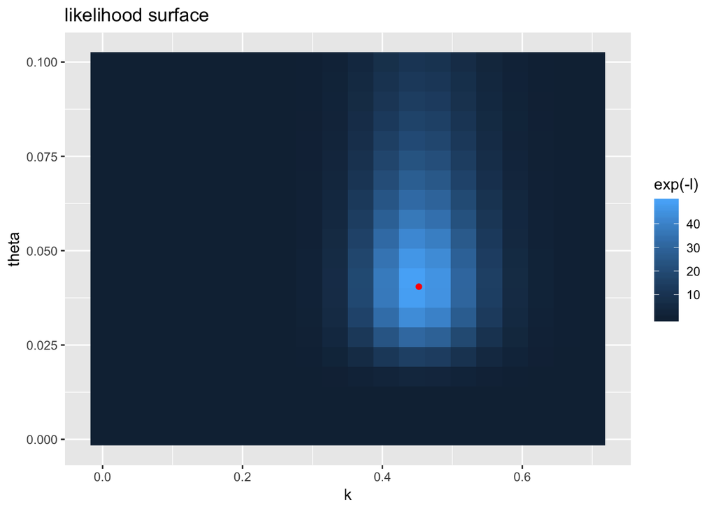

```r
marg.lik <- function(par, data){
    rules <- gauss.quad(30, kind = "hermite")
    w <- rules$nodes
    cl <- sapply(w, cond.likelihood, data = data, k=par[1], theta=par[2])
    -log(sum(rules$weights * exp(w^2) * cl))
}
d <- expand.grid(k = seq(.001, .7, length = 20), theta = seq(.001,.1, length = 20))
d$l <- apply(d, 1, marg.lik, data = df)
try1 <- optim(par = c(1,1),
      fn = marg.lik,
      data = df,
      lower = c(.001,.001),
      method = "L-BFGS-B",
      upper = c(10, 10))
ggplot(d) +
geom_raster(aes(x = k, y = theta, fill = exp(-l)))+
ggtitle("likelihood surface") +
annotate("point", x = try1$par[1], y = try1$par[2], color = "red")
```